# Practical: What is R

### Base plotting

5. Creating a histograms of numeric variables.

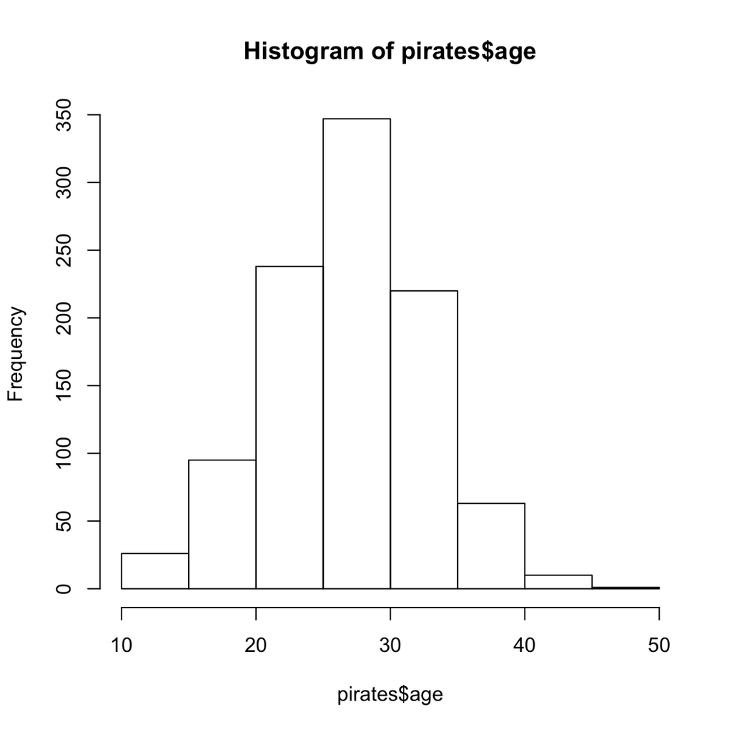

```r
# --- A default histogram of pirate ages
hist(x = pirates$age)
```

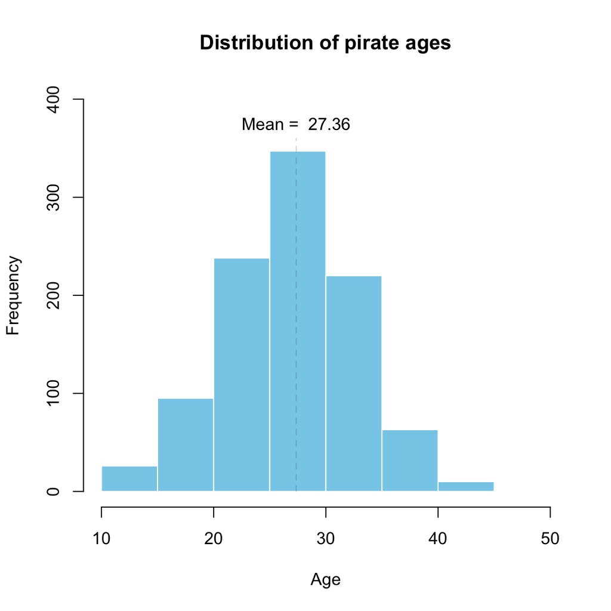

```r
# --- A customized histogram of pirate ages
hist(x = pirates$age,
     main = "Distribution of pirate ages",
     col = "skyblue",
     border = "white",
     xlab = "Age",
     ylim = c(0, 400))

# Add mean label
text(x = mean(pirates$age), y = 375,
     labels = paste("Mean = ", round(mean(pirates$age), 2)))

# Add dashed line at mean
segments(x0 = mean(pirates$age), y0 = 0,
         x1 = mean(pirates$age), y1 = 360,
         col = gray(.2, .2),
         lty = 2)
```

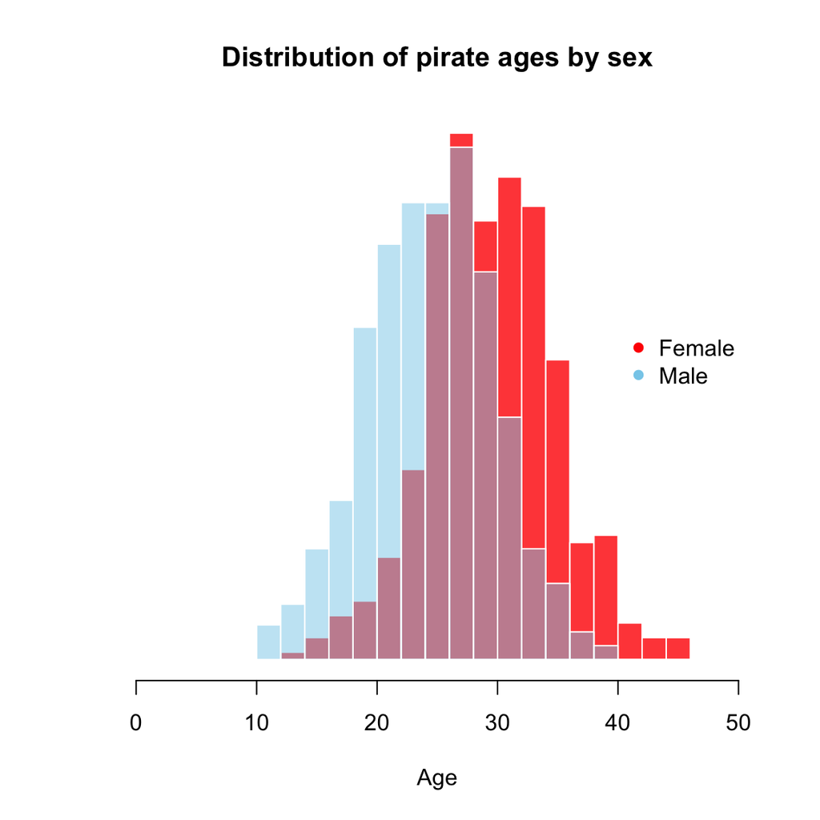

```r
# ---- Overlapping histograms of pirate ages for females and males

# Start with the female data
hist(x = pirates$age[pirates$sex == "female"],
     main = "Distribution of pirate ages by sex",
     col = transparent("red", .2),
     border = "white",
     xlab = "Age",
     breaks = seq(0, 50, 2),
     probability = T,
     ylab = "",
     yaxt = "n")

# Add male data
hist(x = pirates$age[pirates$sex == "male"],
     add = T,
     probability = T,
     border = "white",
     breaks = seq(0, 50, 2),
     col = transparent("skyblue", .5))

# Add the legend
legend(x = 40,
       y = .05,
       col = c("red", "skyblue"),
       legend = c("Female", "Male"),
       pch = 16,
       bty = "n")
```

6. Creating scatterplots of two numerical variables.

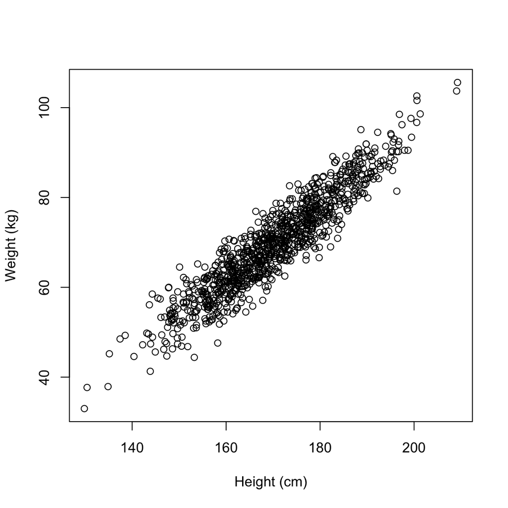

```r
# --- A simple scatterplot of pirate height and weight
plot(x = pirates$height,
     y = pirates$weight,
     xlab = "Height (cm)",
     ylab = "Weight (kg)")
```

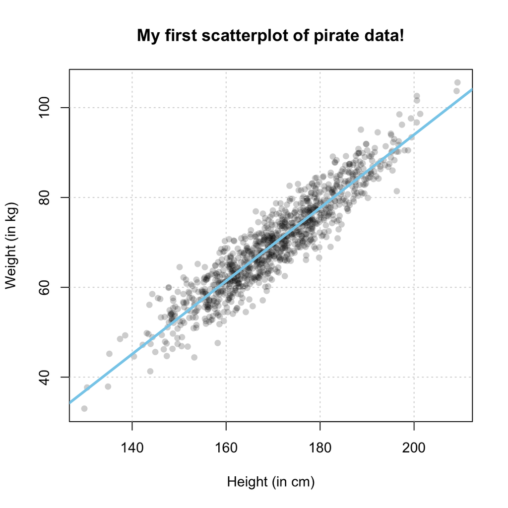

```r
# --- A fancier scatterplot of the same data with some additional arguments

# Create main plot
plot(x = pirates$height,
     y = pirates$weight,
     main = 'My first scatterplot of pirate data!',
     xlab = 'Height (in cm)',
     ylab = 'Weight (in kg)',
     pch = 16,    # Filled circles
     col = gray(0, .2)) # Transparent gray

# Add gridlines
grid()

# Create a linear regression model
model <- lm(formula = weight ~ height,
            data = pirates)

# Add regression to plot
abline(model,
       col = 'skyblue', lwd = 3)
```

7. Changing colors

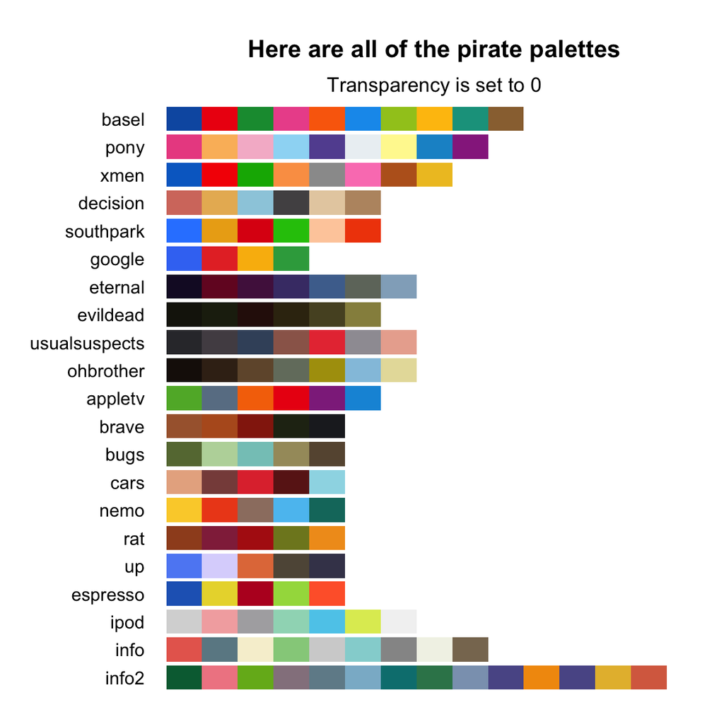

```r
# --- Look at all the palettes from piratepal()
piratepal()
```

[figure not shown]

```r
# Look at the basel palette in detail
piratepal(palette = "basel", plot.result = TRUE)
```

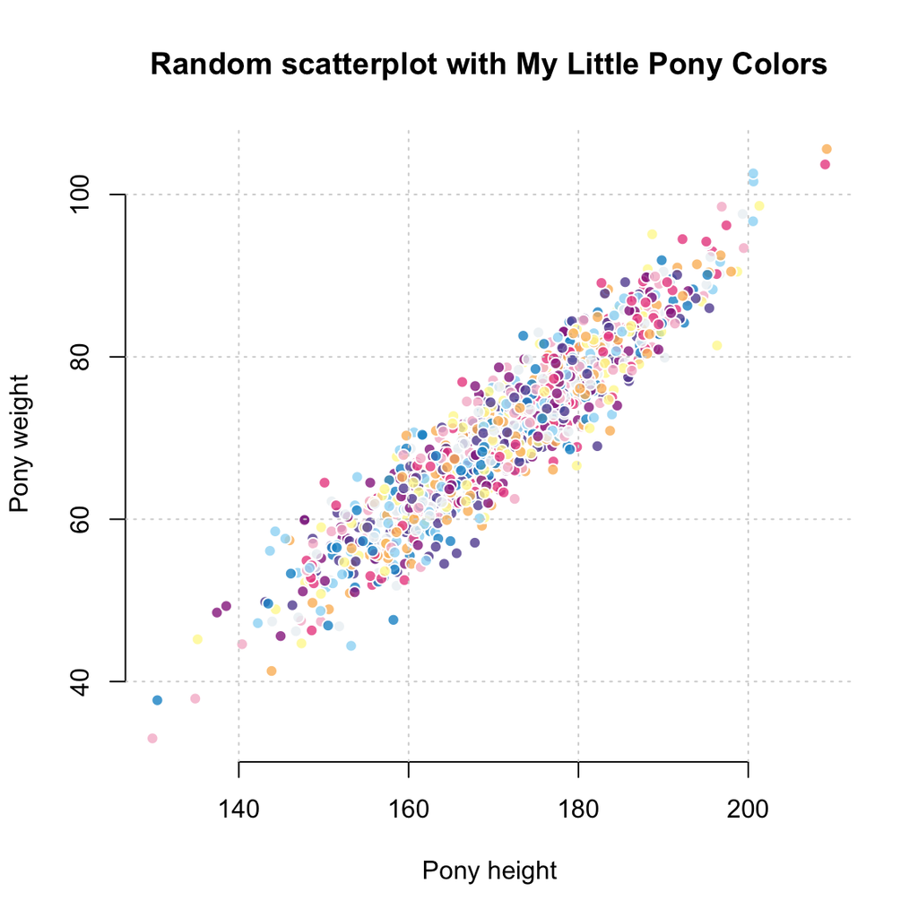

```r
# --- Scatterplot of pirate height and weight using the pony palette
my.cols <- piratepal(palette = "pony",
                     trans = .2,
                     length.out = nrow(pirates))

# Create the plot
plot(x = pirates$height, y = pirates$weight,
     main = "Random scatterplot with My Little Pony Colors",
     xlab = "Pony height",
     ylab = "Pony weight",
     pch = 21,  # Round symbols with borders
     col = "white",  # White border
     bg = my.cols,  # Random colors
     bty = "n"  # No plot border
     )

# Add gridlines
grid()
```

8. Create a barplot for stratified data

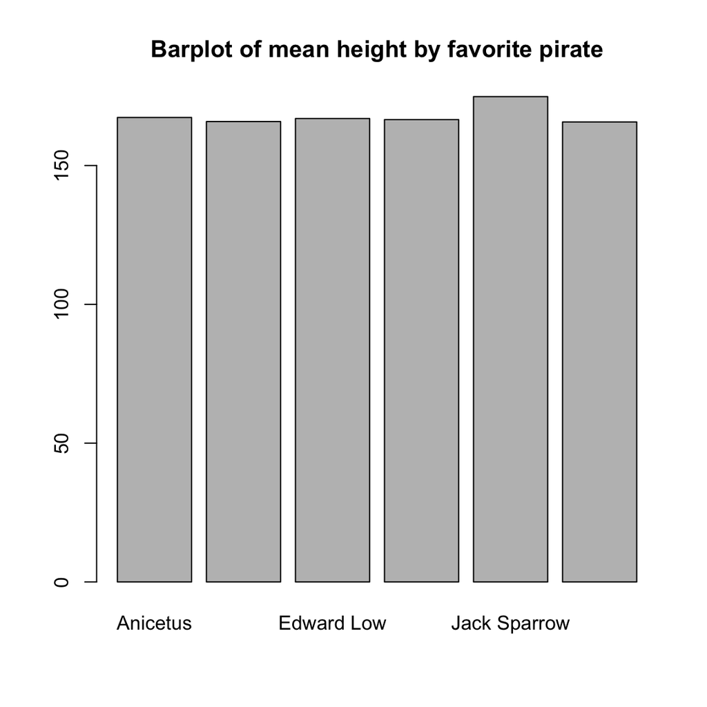

```r
# --- Barpot of mean height by favorite.pirate

# Calculate mean height for each favorite.pirate
pirate_heights <- aggregate(height ~ favorite.pirate,
                     data = pirates,
                     FUN = mean)

# Do barplot
barplot(pirate_heights$height,
        main = "Barplot of mean height by favorite pirate",
        names.arg = pirate_heights$favorite.pirate)
```

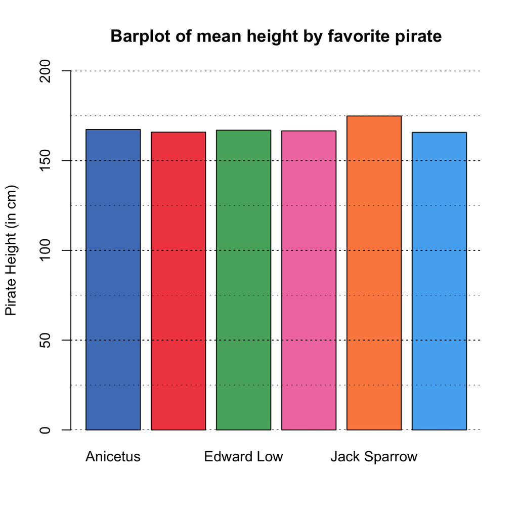

```r
# --- Same, but with customizations
barplot(pirate_heights$height,
        ylim = c(0, 200),
        ylab = "Pirate Height (in cm)",
        main = "Barplot of mean height by favorite pirate",
        names.arg = pirate_heights$favorite.pirate,
        col = piratepal("basel", trans = .2))

abline(h = seq(0, 200, 25), lty = 3, lwd = c(1, .5))
```

### Hypothesis testing

9. Run a group comparisons.

```r
# Do pirates with eyepatches have longer beards than those without eyepatches?
t.test(formula = beard.length ~ eyepatch,
       data = pirates,
       alternative = 'two.sided')
```

```
    Welch Two Sample t-test

data:  beard.length by eyepatch
t = 1.4404, df = 674.27, p-value = 0.1502
alternative hypothesis: true difference in means is not equal to 0
95 percent confidence interval:
 -0.3625525  2.3593174
sample estimates:
mean in group 0 mean in group 1
       11.04094        10.04255
```

```r
# ANOVA on beard.length as a function of sex and college

# Run the ANOVA
beard_aov <- aov(formula = beard.length ~ sex + college,
                   data = pirates)

# Print summary results
summary(beard_aov)
```

```
             Df Sum Sq Mean Sq  F value Pr(>F)
sex           2  87174   43587 2276.901 <2e-16 ***
college       1     12      12    0.641  0.424
Residuals   996  19067      19
---
Signif. codes:  0 '***' 0.001 '**' 0.01 '*' 0.05 '.' 0.1 ' ' 1
```

10. Run a regression analysis.

```r
# regression analysis showing if age, weight, and tattoos predict how many treasure chests a pirate has found

# Run the regression
chests_lm <- lm(formula = tchests ~ age + weight + tattoos,
                data = pirates)

# Print summary results
summary(chests_lm)
```

```
Call:
lm(formula = tchests ~ age + weight + tattoos, data = pirates)

Residuals:
    Min      1Q  Median      3Q     Max
-33.302 -15.832  -6.860   8.407 119.966

Coefficients:
            Estimate Std. Error t value Pr(>|t|)
(Intercept)  5.19084    7.18437   0.723     0.47
age          0.78177    0.13438   5.818 8.03e-09 ***
weight      -0.09013    0.07183  -1.255     0.21
tattoos      0.25398    0.22550   1.126     0.26
---
Signif. codes:  0 '***' 0.001 '**' 0.01 '*' 0.05 '.' 0.1 ' ' 1

Residual standard error: 23.99 on 996 degrees of freedom
Multiple R-squared:  0.04056,   Adjusted R-squared:  0.03767
F-statistic: 14.04 on 3 and 996 DF,  p-value: 5.751e-09
```

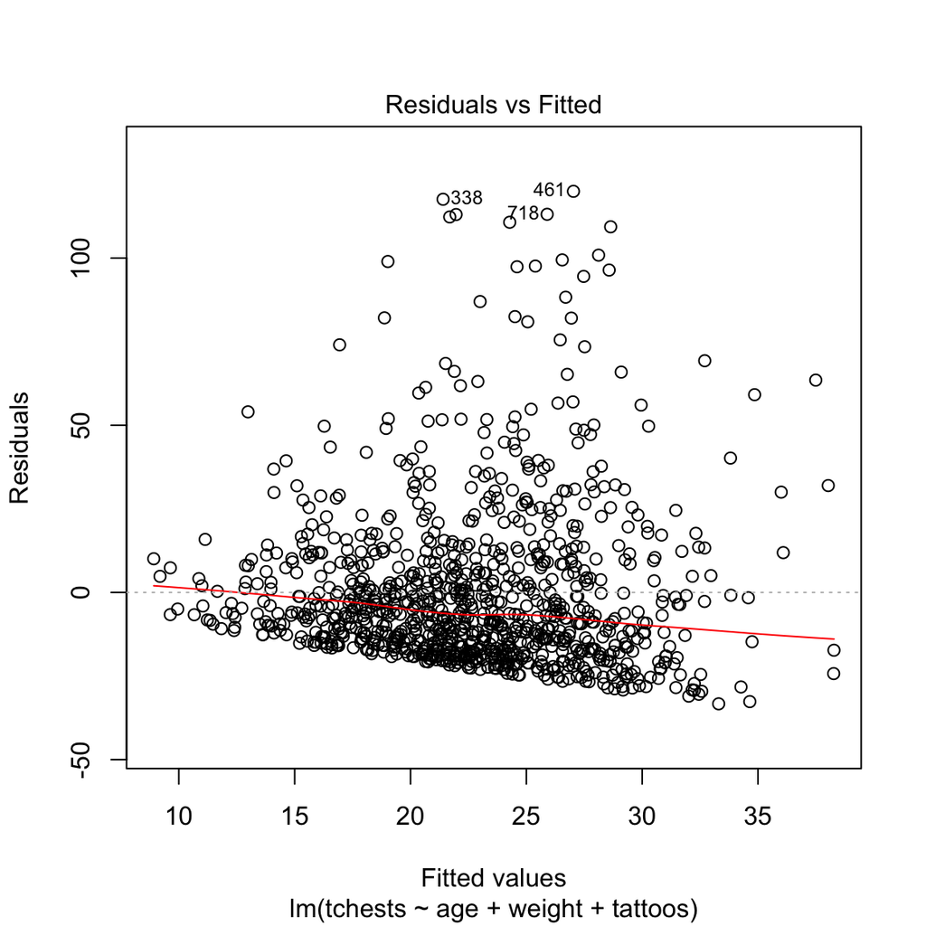

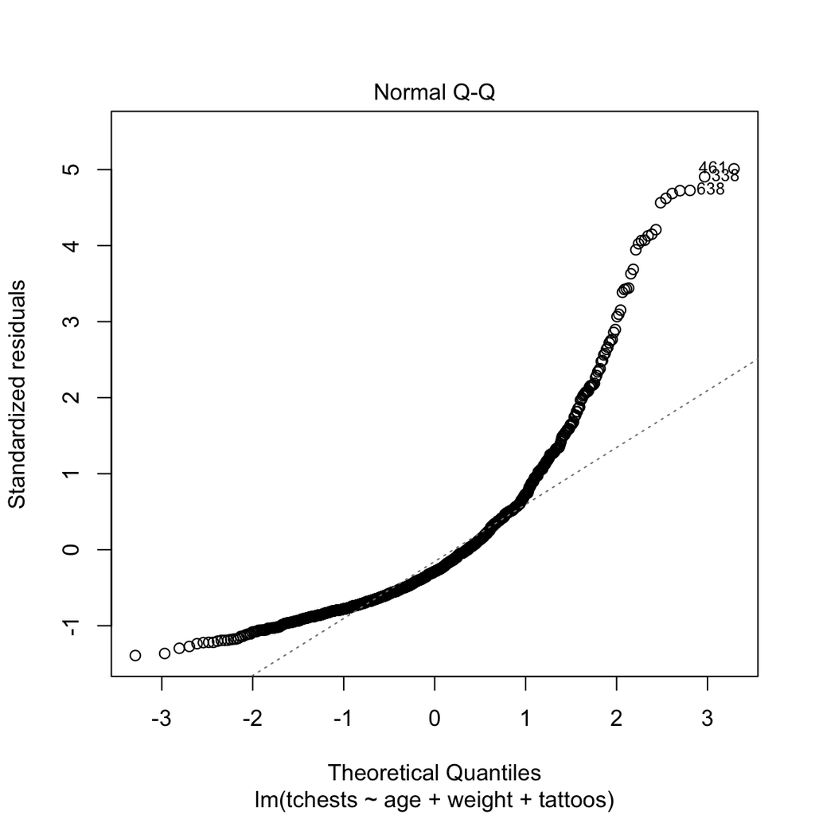

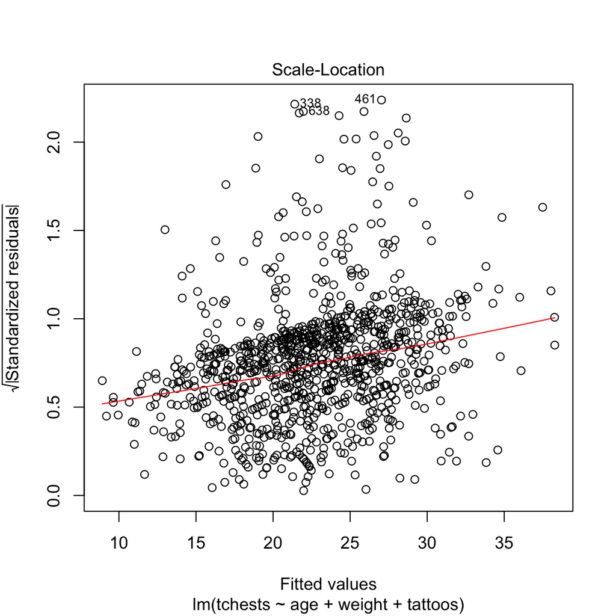

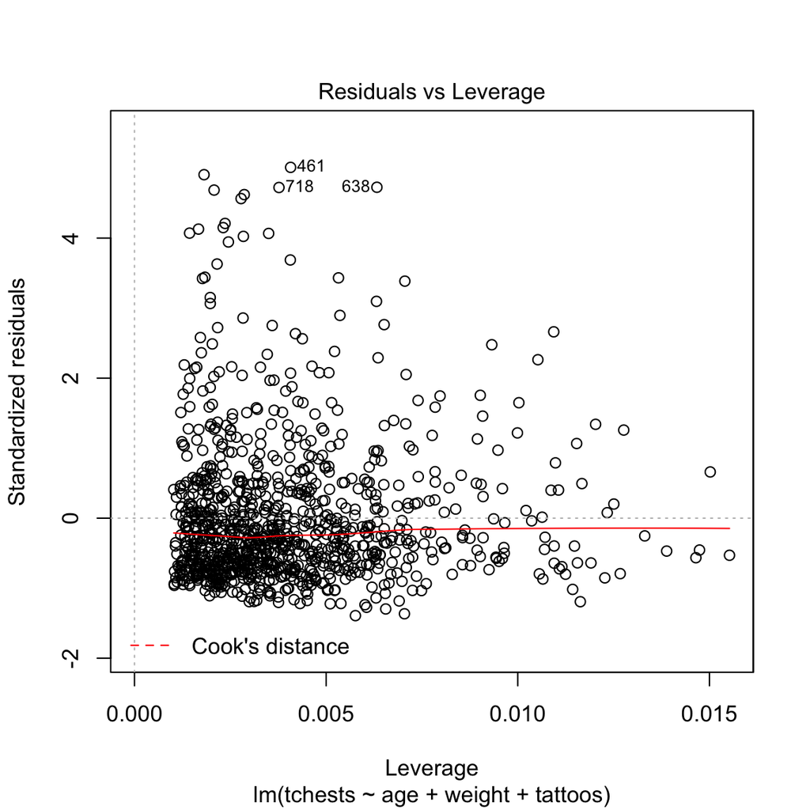

```r
# Plot regression (continue with <Return>)
plot(chests_lm)
```

# Additional reading

- For more details on all steps of data analysis check out Hadley Wickham’s [R for Data Science](http://r4ds.had.co.nz/).
- For more on pirates and data analysis check out the respective chapters in YaRrr! The Pirate’s Guide to R [YaRrr! Chapter Link](https://bookdown.org/ndphillips/YaRrr/htests.html)